# Risk Factor Analysis

## Outcome Variable

**Outcome Variable:** whz

## Predictor Variables

**Intervention Variable:** fage

**Adjustment Set:**

- arm
- W_mage
- meducyrs
- feducyrs
- W_mhtcm
- W_mwtkg
- W_mbmi
- W_fhtcm
- single
- brthmon
- delta_W_mage
- delta_meducyrs
- delta_feducyrs
- delta_W_mhtcm
- delta_W_mwtkg
- delta_W_mbmi
- delta_W_fhtcm
- delta_single
- delta_brthmon

## Stratifying Variables

The analysis was stratified on these variable(s):

- agecat
- studyid
- country

## Data Summary

| agecat | studyid | country | fage | n_cell | n |
| --- | --- | --- | --- | --- | --- |
| Birth | ki0047075b-MAL-ED | BANGLADESH | >=38 | 61 | 128 |
| Birth | ki0047075b-MAL-ED | BANGLADESH | <32 | 23 | 128 |
| Birth | ki0047075b-MAL-ED | BANGLADESH | [32-38) | 44 | 128 |
| Birth | ki0047075b-MAL-ED | BRAZIL | >=38 | 5 | 16 |
| Birth | ki0047075b-MAL-ED | BRAZIL | <32 | 1 | 16 |
| Birth | ki0047075b-MAL-ED | BRAZIL | [32-38) | 10 | 16 |
| Birth | ki0047075b-MAL-ED | INDIA | >=38 | 7 | 25 |
| Birth | ki0047075b-MAL-ED | INDIA | <32 | 8 | 25 |
| Birth | ki0047075b-MAL-ED | INDIA | [32-38) | 10 | 25 |
| Birth | ki0047075b-MAL-ED | NEPAL | >=38 | 2 | 9 |
| Birth | ki0047075b-MAL-ED | NEPAL | <32 | 2 | 9 |
| Birth | ki0047075b-MAL-ED | NEPAL | [32-38) | 5 | 9 |
| Birth | ki0047075b-MAL-ED | PERU | >=38 | 23 | 67 |
| Birth | ki0047075b-MAL-ED | PERU | <32 | 21 | 67 |
| Birth | ki0047075b-MAL-ED | PERU | [32-38) | 23 | 67 |
| Birth | ki0047075b-MAL-ED | SOUTH AFRICA | >=38 | 16 | 30 |
| Birth | ki0047075b-MAL-ED | SOUTH AFRICA | <32 | 5 | 30 |
| Birth | ki0047075b-MAL-ED | SOUTH AFRICA | [32-38) | 9 | 30 |
| Birth | ki0047075b-MAL-ED | TANZANIA, UNITED REPUBLIC OF | >=38 | 17 | 44 |
| Birth | ki0047075b-MAL-ED | TANZANIA, UNITED REPUBLIC OF | <32 | 9 | 44 |
| Birth | ki0047075b-MAL-ED | TANZANIA, UNITED REPUBLIC OF | [32-38) | 18 | 44 |
| Birth | ki1000304b-SAS-CompFeed | INDIA | >=38 | 34 | 1101 |
| Birth | ki1000304b-SAS-CompFeed | INDIA | <32 | 923 | 1101 |
| Birth | ki1000304b-SAS-CompFeed | INDIA | [32-38) | 144 | 1101 |
| Birth | ki1119695-PROBIT | BELARUS | >=38 | 606 | 13339 |
| Birth | ki1119695-PROBIT | BELARUS | <32 | 10681 | 13339 |
| Birth | ki1119695-PROBIT | BELARUS | [32-38) | 2052 | 13339 |
| Birth | ki1135781-COHORTS | GUATEMALA | >=38 | 222 | 735 |
| Birth | ki1135781-COHORTS | GUATEMALA | <32 | 337 | 735 |
| Birth | ki1135781-COHORTS | GUATEMALA | [32-38) | 176 | 735 |

[output cut: 75 more lines]

The following strata were considered:

- agecat: 24 months, studyid: ki0047075b-MAL-ED, country: BANGLADESH
- agecat: 24 months, studyid: ki0047075b-MAL-ED, country: BRAZIL
- agecat: 24 months, studyid: ki0047075b-MAL-ED, country: INDIA
- agecat: 24 months, studyid: ki0047075b-MAL-ED, country: NEPAL
- agecat: 24 months, studyid: ki0047075b-MAL-ED, country: PERU
- agecat: 24 months, studyid: ki0047075b-MAL-ED, country: SOUTH AFRICA
- agecat: 24 months, studyid: ki0047075b-MAL-ED, country: TANZANIA, UNITED REPUBLIC OF
- agecat: 24 months, studyid: ki1119695-PROBIT, country: BELARUS
- agecat: 24 months, studyid: ki1135781-COHORTS, country: GUATEMALA
- agecat: 24 months, studyid: ki1135781-COHORTS, country: PHILIPPINES
- agecat: 24 months, studyid: ki1148112-LCNI-5, country: MALAWI
- agecat: 6 months, studyid: ki0047075b-MAL-ED, country: BANGLADESH
- agecat: 6 months, studyid: ki0047075b-MAL-ED, country: BRAZIL
- agecat: 6 months, studyid: ki0047075b-MAL-ED, country: INDIA
- agecat: 6 months, studyid: ki0047075b-MAL-ED, country: NEPAL
- agecat: 6 months, studyid: ki0047075b-MAL-ED, country: PERU
- agecat: 6 months, studyid: ki0047075b-MAL-ED, country: SOUTH AFRICA
- agecat: 6 months, studyid: ki0047075b-MAL-ED, country: TANZANIA, UNITED REPUBLIC OF
- agecat: 6 months, studyid: ki1000304b-SAS-CompFeed, country: INDIA
- agecat: 6 months, studyid: ki1000304b-SAS-FoodSuppl, country: INDIA
- agecat: 6 months, studyid: ki1119695-PROBIT, country: BELARUS
- agecat: 6 months, studyid: ki1135781-COHORTS, country: GUATEMALA
- agecat: 6 months, studyid: ki1135781-COHORTS, country: PHILIPPINES
- agecat: 6 months, studyid: ki1148112-LCNI-5, country: MALAWI
- agecat: Birth, studyid: ki0047075b-MAL-ED, country: BANGLADESH
- agecat: Birth, studyid: ki0047075b-MAL-ED, country: BRAZIL
- agecat: Birth, studyid: ki0047075b-MAL-ED, country: INDIA
- agecat: Birth, studyid: ki0047075b-MAL-ED, country: NEPAL
- agecat: Birth, studyid: ki0047075b-MAL-ED, country: PERU
- agecat: Birth, studyid: ki0047075b-MAL-ED, country: SOUTH AFRICA
- agecat: Birth, studyid: ki0047075b-MAL-ED, country: TANZANIA, UNITED REPUBLIC OF
- agecat: Birth, studyid: ki1000304b-SAS-CompFeed, country: INDIA
- agecat: Birth, studyid: ki1119695-PROBIT, country: BELARUS
- agecat: Birth, studyid: ki1135781-COHORTS, country: GUATEMALA
- agecat: Birth, studyid: ki1135781-COHORTS, country: PHILIPPINES

### Dropped Strata

Some strata were dropped due to rare outcomes:

- agecat: Birth, studyid: ki0047075b-MAL-ED, country: BRAZIL
- agecat: Birth, studyid: ki0047075b-MAL-ED, country: NEPAL

## Methods Detail

We’re interested in the causal parameters $E[Y_a]$ for all values of $a \in \mathcal{A}$. These parameters represent the mean outcome if, possibly contrary to fact, we intervened to set all units to have $A=a$. Under the randomization and positivity assumptions, these are identified by the statistical parameters $\psi_a=E_W[E_{Y|A,W}(Y|A=a,W)]$. In addition, we’re interested in the mean of $Y$, $E[Y]$ under no intervention (the observed mean). We will estimate these parameters by using SuperLearner to fit the relevant likelihood factors – $E_{Y|A,W}(Y|A=a,W)$ and $p(A=a|W)$, and then updating our likelihood fit using a joint TMLE.

For unadjusted analyses ($W=\{\}$), initial likelihoods were estimated using Lrnr_glm to estimate the simple $E(Y|A)$ and Lrnr_mean to estimate $p(A)$. For adjusted analyses, a small library containing Lrnr_glmnet, Lrnr_xgboost, and Lrnr_mean was used.

Having estimated these parameters, we will then use the delta method to estimate relative risks and attributable risks relative to a prespecified baseline level of $A$.

# Results Detail

## Results Plots

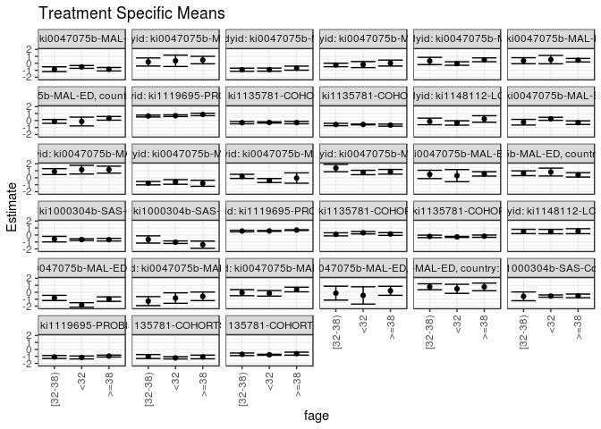

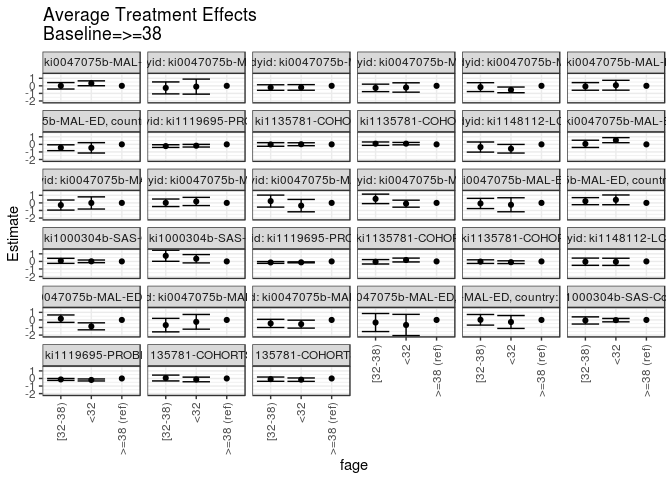

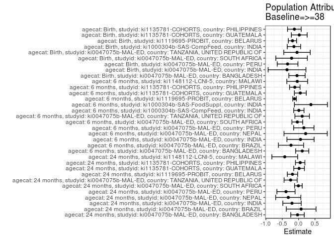

## Results Table

### Parameter: TSM

| agecat | studyid | country | intervention_level | baseline_level | estimate | ci_lower | ci_upper |
| --- | --- | --- | --- | --- | --- | --- | --- |
| Birth | ki0047075b-MAL-ED | BANGLADESH | >=38 | NA | -0.9887782 | -1.3054455 | -0.6721110 |
| Birth | ki0047075b-MAL-ED | BANGLADESH | <32 | NA | -1.8352316 | -2.1675041 | -1.5029592 |
| Birth | ki0047075b-MAL-ED | BANGLADESH | [32-38) | NA | -0.8215762 | -1.1943134 | -0.4488390 |
| Birth | ki0047075b-MAL-ED | INDIA | >=38 | NA | -0.5928571 | -1.2084707 | 0.0227564 |
| Birth | ki0047075b-MAL-ED | INDIA | <32 | NA | -0.8425000 | -1.5949041 | -0.0900959 |
| Birth | ki0047075b-MAL-ED | INDIA | [32-38) | NA | -1.2770000 | -1.9214891 | -0.6325109 |
| Birth | ki0047075b-MAL-ED | PERU | >=38 | NA | 0.3901094 | 0.0551023 | 0.7251165 |
| Birth | ki0047075b-MAL-ED | PERU | <32 | NA | -0.1622290 | -0.5624735 | 0.2380155 |
| Birth | ki0047075b-MAL-ED | PERU | [32-38) | NA | -0.0681779 | -0.4968938 | 0.3605381 |
| Birth | ki0047075b-MAL-ED | SOUTH AFRICA | >=38 | NA | 0.2062500 | -0.4416802 | 0.8541802 |
| Birth | ki0047075b-MAL-ED | SOUTH AFRICA | <32 | NA | -0.4600000 | -1.7036186 | 0.7836186 |
| Birth | ki0047075b-MAL-ED | SOUTH AFRICA | [32-38) | NA | -0.1355556 | -1.1366672 | 0.8655561 |
| Birth | ki0047075b-MAL-ED | TANZANIA, UNITED REPUBLIC OF | >=38 | NA | 0.7594118 | 0.2105891 | 1.3082344 |
| Birth | ki0047075b-MAL-ED | TANZANIA, UNITED REPUBLIC OF | <32 | NA | 0.4877778 | -0.1646330 | 1.1401886 |
| Birth | ki0047075b-MAL-ED | TANZANIA, UNITED REPUBLIC OF | [32-38) | NA | 0.7783333 | 0.3478361 | 1.2088306 |
| Birth | ki1000304b-SAS-CompFeed | INDIA | >=38 | NA | -0.5264390 | -0.7893166 | -0.2635614 |
| Birth | ki1000304b-SAS-CompFeed | INDIA | <32 | NA | -0.5527289 | -0.7163628 | -0.3890950 |
| Birth | ki1000304b-SAS-CompFeed | INDIA | [32-38) | NA | -0.5932451 | -1.2258433 | 0.0393531 |
| Birth | ki1119695-PROBIT | BELARUS | >=38 | NA | -0.9530008 | -1.0915983 | -0.8144034 |
| Birth | ki1119695-PROBIT | BELARUS | <32 | NA | -1.1485742 | -1.3569846 | -0.9401637 |
| Birth | ki1119695-PROBIT | BELARUS | [32-38) | NA | -1.0826810 | -1.2944425 | -0.8709194 |
| Birth | ki1135781-COHORTS | GUATEMALA | >=38 | NA | -1.0793004 | -1.3439380 | -0.8146628 |
| Birth | ki1135781-COHORTS | GUATEMALA | <32 | NA | -1.2105037 | -1.3667824 | -1.0542250 |
| Birth | ki1135781-COHORTS | GUATEMALA | [32-38) | NA | -1.0192333 | -1.3025431 | -0.7359235 |
| Birth | ki1135781-COHORTS | PHILIPPINES | >=38 | NA | -0.6020414 | -0.8151161 | -0.3889668 |
| Birth | ki1135781-COHORTS | PHILIPPINES | <32 | NA | -0.7623357 | -0.8292139 | -0.6954574 |
| Birth | ki1135781-COHORTS | PHILIPPINES | [32-38) | NA | -0.6959203 | -0.8787576 | -0.5130831 |
| 6 months | ki0047075b-MAL-ED | BANGLADESH | >=38 | NA | -0.3067993 | -0.5616002 | -0.0519984 |
| 6 months | ki0047075b-MAL-ED | BANGLADESH | <32 | NA | 0.2496256 | 0.0336728 | 0.4655784 |
| 6 months | ki0047075b-MAL-ED | BANGLADESH | [32-38) | NA | -0.2408448 | -0.6460277 | 0.1643382 |

[output cut: 69 more lines]

### Parameter: E(Y)

| agecat | studyid | country | intervention_level | baseline_level | estimate | ci_lower | ci_upper |
| --- | --- | --- | --- | --- | --- | --- | --- |
| Birth | ki0047075b-MAL-ED | BANGLADESH | NA | NA | -1.0375000 | -1.2165024 | -0.8584976 |
| Birth | ki0047075b-MAL-ED | INDIA | NA | NA | -0.9464000 | -1.3554144 | -0.5373856 |
| Birth | ki0047075b-MAL-ED | PERU | NA | NA | 0.0529851 | -0.1628445 | 0.2688147 |
| Birth | ki0047075b-MAL-ED | SOUTH AFRICA | NA | NA | -0.0073333 | -0.5181900 | 0.5035233 |
| Birth | ki0047075b-MAL-ED | TANZANIA, UNITED REPUBLIC OF | NA | NA | 0.7115909 | 0.4034609 | 1.0197209 |
| Birth | ki1000304b-SAS-CompFeed | INDIA | NA | NA | -0.6685468 | -0.8459689 | -0.4911247 |
| Birth | ki1119695-PROBIT | BELARUS | NA | NA | -1.1395817 | -1.3497976 | -0.9293658 |
| Birth | ki1135781-COHORTS | GUATEMALA | NA | NA | -1.0580408 | -1.1607065 | -0.9553751 |
| Birth | ki1135781-COHORTS | PHILIPPINES | NA | NA | -0.7309760 | -0.7780724 | -0.6838797 |
| 6 months | ki0047075b-MAL-ED | BANGLADESH | NA | NA | -0.1950111 | -0.3575506 | -0.0324716 |
| 6 months | ki0047075b-MAL-ED | BRAZIL | NA | NA | 0.9365401 | 0.6541549 | 1.2189253 |
| 6 months | ki0047075b-MAL-ED | INDIA | NA | NA | -0.7292288 | -0.8803893 | -0.5780683 |
| 6 months | ki0047075b-MAL-ED | NEPAL | NA | NA | 0.1749789 | -0.0644624 | 0.4144202 |
| 6 months | ki0047075b-MAL-ED | PERU | NA | NA | 1.0182129 | 0.7827641 | 1.2536616 |
| 6 months | ki0047075b-MAL-ED | SOUTH AFRICA | NA | NA | 0.5158052 | 0.2517895 | 0.7798210 |
| 6 months | ki0047075b-MAL-ED | TANZANIA, UNITED REPUBLIC OF | NA | NA | 0.5271500 | 0.3177522 | 0.7365478 |
| 6 months | ki1000304b-SAS-CompFeed | INDIA | NA | NA | -0.6641059 | -0.8040033 | -0.5242086 |
| 6 months | ki1000304b-SAS-FoodSuppl | INDIA | NA | NA | -1.0121579 | -1.1280429 | -0.8962729 |
| 6 months | ki1119695-PROBIT | BELARUS | NA | NA | 0.5785982 | 0.5189015 | 0.6382948 |
| 6 months | ki1135781-COHORTS | GUATEMALA | NA | NA | 0.1925914 | 0.1205037 | 0.2646791 |
| 6 months | ki1135781-COHORTS | PHILIPPINES | NA | NA | -0.2878032 | -0.3296319 | -0.2459745 |
| 6 months | ki1148112-LCNI-5 | MALAWI | NA | NA | 0.5060377 | 0.3131397 | 0.6989358 |
| 24 months | ki0047075b-MAL-ED | BANGLADESH | NA | NA | -0.8844702 | -1.0263143 | -0.7426261 |
| 24 months | ki0047075b-MAL-ED | BRAZIL | NA | NA | 0.5448101 | 0.2082313 | 0.8813890 |
| 24 months | ki0047075b-MAL-ED | INDIA | NA | NA | -0.8968012 | -1.0287307 | -0.7648718 |
| 24 months | ki0047075b-MAL-ED | NEPAL | NA | NA | -0.2794304 | -0.4767398 | -0.0821210 |
| 24 months | ki0047075b-MAL-ED | PERU | NA | NA | 0.1198207 | -0.0845120 | 0.3241534 |
| 24 months | ki0047075b-MAL-ED | SOUTH AFRICA | NA | NA | 0.4414045 | 0.2336389 | 0.6491701 |
| 24 months | ki0047075b-MAL-ED | TANZANIA, UNITED REPUBLIC OF | NA | NA | 0.0766500 | -0.1115307 | 0.2648307 |
| 24 months | ki1119695-PROBIT | BELARUS | NA | NA | 0.6857534 | 0.5745271 | 0.7969798 |
| 24 months | ki1135781-COHORTS | GUATEMALA | NA | NA | -0.2760853 | -0.3311930 | -0.2209775 |
| 24 months | ki1135781-COHORTS | PHILIPPINES | NA | NA | -0.6087584 | -0.6459824 | -0.5715345 |
| 24 months | ki1148112-LCNI-5 | MALAWI | NA | NA | -0.1979730 | -0.4244675 | 0.0285215 |

### Parameter: ATE

| agecat | studyid | country | intervention_level | baseline_level | estimate | ci_lower | ci_upper |
| --- | --- | --- | --- | --- | --- | --- | --- |
| Birth | ki0047075b-MAL-ED | BANGLADESH | >=38 | >=38 | 0.0000000 | 0.0000000 | 0.0000000 |
| Birth | ki0047075b-MAL-ED | BANGLADESH | <32 | >=38 | -0.8464534 | -1.3092348 | -0.3836720 |
| Birth | ki0047075b-MAL-ED | BANGLADESH | [32-38) | >=38 | 0.1672020 | -0.3246346 | 0.6590387 |
| Birth | ki0047075b-MAL-ED | INDIA | >=38 | >=38 | 0.0000000 | 0.0000000 | 0.0000000 |
| Birth | ki0047075b-MAL-ED | INDIA | <32 | >=38 | -0.2496429 | -1.2218012 | 0.7225155 |
| Birth | ki0047075b-MAL-ED | INDIA | [32-38) | >=38 | -0.6841429 | -1.5754039 | 0.2071182 |
| Birth | ki0047075b-MAL-ED | PERU | >=38 | >=38 | 0.0000000 | 0.0000000 | 0.0000000 |
| Birth | ki0047075b-MAL-ED | PERU | <32 | >=38 | -0.5523384 | -1.0756646 | -0.0290122 |
| Birth | ki0047075b-MAL-ED | PERU | [32-38) | >=38 | -0.4582872 | -0.9975301 | 0.0809556 |
| Birth | ki0047075b-MAL-ED | SOUTH AFRICA | >=38 | >=38 | 0.0000000 | 0.0000000 | 0.0000000 |
| Birth | ki0047075b-MAL-ED | SOUTH AFRICA | <32 | >=38 | -0.6662500 | -2.0685341 | 0.7360341 |
| Birth | ki0047075b-MAL-ED | SOUTH AFRICA | [32-38) | >=38 | -0.3418056 | -1.5342979 | 0.8506868 |
| Birth | ki0047075b-MAL-ED | TANZANIA, UNITED REPUBLIC OF | >=38 | >=38 | 0.0000000 | 0.0000000 | 0.0000000 |
| Birth | ki0047075b-MAL-ED | TANZANIA, UNITED REPUBLIC OF | <32 | >=38 | -0.2716340 | -1.1241867 | 0.5809187 |
| Birth | ki0047075b-MAL-ED | TANZANIA, UNITED REPUBLIC OF | [32-38) | >=38 | 0.0189216 | -0.6785984 | 0.7164416 |
| Birth | ki1000304b-SAS-CompFeed | INDIA | >=38 | >=38 | 0.0000000 | 0.0000000 | 0.0000000 |
| Birth | ki1000304b-SAS-CompFeed | INDIA | <32 | >=38 | -0.0262900 | -0.2486392 | 0.1960593 |
| Birth | ki1000304b-SAS-CompFeed | INDIA | [32-38) | >=38 | -0.0668061 | -0.5391138 | 0.4055016 |
| Birth | ki1119695-PROBIT | BELARUS | >=38 | >=38 | 0.0000000 | 0.0000000 | 0.0000000 |
| Birth | ki1119695-PROBIT | BELARUS | <32 | >=38 | -0.1955733 | -0.3279865 | -0.0631602 |
| Birth | ki1119695-PROBIT | BELARUS | [32-38) | >=38 | -0.1296801 | -0.2556530 | -0.0037072 |
| Birth | ki1135781-COHORTS | GUATEMALA | >=38 | >=38 | 0.0000000 | 0.0000000 | 0.0000000 |
| Birth | ki1135781-COHORTS | GUATEMALA | <32 | >=38 | -0.1312033 | -0.4383592 | 0.1759525 |
| Birth | ki1135781-COHORTS | GUATEMALA | [32-38) | >=38 | 0.0600671 | -0.3269866 | 0.4471209 |
| Birth | ki1135781-COHORTS | PHILIPPINES | >=38 | >=38 | 0.0000000 | 0.0000000 | 0.0000000 |
| Birth | ki1135781-COHORTS | PHILIPPINES | <32 | >=38 | -0.1602943 | -0.3837787 | 0.0631901 |
| Birth | ki1135781-COHORTS | PHILIPPINES | [32-38) | >=38 | -0.0938789 | -0.3749078 | 0.1871500 |
| 6 months | ki0047075b-MAL-ED | BANGLADESH | >=38 | >=38 | 0.0000000 | 0.0000000 | 0.0000000 |
| 6 months | ki0047075b-MAL-ED | BANGLADESH | <32 | >=38 | 0.5564249 | 0.2224338 | 0.8904160 |
| 6 months | ki0047075b-MAL-ED | BANGLADESH | [32-38) | >=38 | 0.0659546 | -0.4111988 | 0.5431080 |

[output cut: 69 more lines]

### Parameter: PAR

| agecat | studyid | country | intervention_level | baseline_level | estimate | ci_lower | ci_upper |
| --- | --- | --- | --- | --- | --- | --- | --- |
| Birth | ki0047075b-MAL-ED | BANGLADESH | >=38 | NA | -0.0487218 | -0.2974042 | 0.1999607 |
| Birth | ki0047075b-MAL-ED | INDIA | >=38 | NA | -0.3535429 | -0.9315083 | 0.2244226 |
| Birth | ki0047075b-MAL-ED | PERU | >=38 | NA | -0.3371243 | -0.6541289 | -0.0201198 |
| Birth | ki0047075b-MAL-ED | SOUTH AFRICA | >=38 | NA | -0.2135833 | -0.6962706 | 0.2691039 |
| Birth | ki0047075b-MAL-ED | TANZANIA, UNITED REPUBLIC OF | >=38 | NA | -0.0478209 | -0.4520486 | 0.3564069 |
| Birth | ki1000304b-SAS-CompFeed | INDIA | >=38 | NA | -0.1421078 | -0.3467024 | 0.0624868 |
| Birth | ki1119695-PROBIT | BELARUS | >=38 | NA | -0.1865808 | -0.3130521 | -0.0601095 |
| Birth | ki1135781-COHORTS | GUATEMALA | >=38 | NA | 0.0212596 | -0.2204823 | 0.2630015 |
| Birth | ki1135781-COHORTS | PHILIPPINES | >=38 | NA | -0.1289346 | -0.3374465 | 0.0795772 |
| 6 months | ki0047075b-MAL-ED | BANGLADESH | >=38 | NA | 0.1117882 | -0.0895723 | 0.3131487 |
| 6 months | ki0047075b-MAL-ED | BRAZIL | >=38 | NA | -0.2316264 | -0.6176180 | 0.1543653 |
| 6 months | ki0047075b-MAL-ED | INDIA | >=38 | NA | 0.0591424 | -0.3559017 | 0.4741865 |
| 6 months | ki0047075b-MAL-ED | NEPAL | >=38 | NA | 0.2158451 | -0.4457891 | 0.8774794 |
| 6 months | ki0047075b-MAL-ED | PERU | >=38 | NA | 0.1606193 | -0.1497807 | 0.4710193 |
| 6 months | ki0047075b-MAL-ED | SOUTH AFRICA | >=38 | NA | -0.0388302 | -0.2037095 | 0.1260492 |
| 6 months | ki0047075b-MAL-ED | TANZANIA, UNITED REPUBLIC OF | >=38 | NA | 0.1097188 | -0.1124659 | 0.3319036 |
| 6 months | ki1000304b-SAS-CompFeed | INDIA | >=38 | NA | 0.0089793 | -0.1479384 | 0.1658971 |
| 6 months | ki1000304b-SAS-FoodSuppl | INDIA | >=38 | NA | 0.3773159 | -0.1275842 | 0.8822161 |
| 6 months | ki1119695-PROBIT | BELARUS | >=38 | NA | -0.1224349 | -0.1778904 | -0.0669794 |
| 6 months | ki1135781-COHORTS | GUATEMALA | >=38 | NA | 0.0529698 | -0.1285377 | 0.2344774 |
| 6 months | ki1135781-COHORTS | PHILIPPINES | >=38 | NA | -0.1161584 | -0.2765577 | 0.0442408 |
| 6 months | ki1148112-LCNI-5 | MALAWI | >=38 | NA | -0.0407735 | -0.3592566 | 0.2777097 |
| 24 months | ki0047075b-MAL-ED | BANGLADESH | >=38 | NA | -0.0326409 | -0.2388714 | 0.1735895 |
| 24 months | ki0047075b-MAL-ED | BRAZIL | >=38 | NA | 0.0785632 | -0.3763499 | 0.5334763 |
| 24 months | ki0047075b-MAL-ED | INDIA | >=38 | NA | -0.2010233 | -0.4817132 | 0.0796667 |
| 24 months | ki0047075b-MAL-ED | NEPAL | >=38 | NA | -0.3157294 | -0.7010495 | 0.0695906 |
| 24 months | ki0047075b-MAL-ED | PERU | >=38 | NA | -0.3850745 | -0.6629145 | -0.1072346 |
| 24 months | ki0047075b-MAL-ED | SOUTH AFRICA | >=38 | NA | -0.0064929 | -0.1236499 | 0.1106640 |
| 24 months | ki0047075b-MAL-ED | TANZANIA, UNITED REPUBLIC OF | >=38 | NA | -0.2438274 | -0.4436434 | -0.0440113 |
| 24 months | ki1119695-PROBIT | BELARUS | >=38 | NA | -0.1868695 | -0.3441749 | -0.0295640 |
| 24 months | ki1135781-COHORTS | GUATEMALA | >=38 | NA | 0.0153885 | -0.1474659 | 0.1782428 |
| 24 months | ki1135781-COHORTS | PHILIPPINES | >=38 | NA | 0.0487491 | -0.0955870 | 0.1930851 |
| 24 months | ki1148112-LCNI-5 | MALAWI | >=38 | NA | -0.4234960 | -0.8175351 | -0.0294569 |